# Premium

### reimbursement = Yes

Für die Erstattungstarife (vermutlich Kurzreiseprodukte) zeigt sich, dass ein Polynom vierten Grades in age ausreichend ist:

```r
lin_modell_I_Yes <- lm(premium ~ poly(age, 4) + type_policy + distribution_channel + gender, dt_I[reimbursement == "Yes"])

summary(lin_modell_I_Yes)
```

```
##
## Call:
## lm(formula = premium ~ poly(age, 4) + type_policy + distribution_channel +
##     gender, data = dt_I[reimbursement == "Yes"])
##
## Residuals:
##     Min      1Q  Median      3Q     Max
## -882.85  -65.27    5.29   42.74  959.23
##
## Coefficients:
##                       Estimate Std. Error t value Pr(>|t|)
## (Intercept)            327.649      8.445  38.797  < 2e-16 ***
## poly(age, 4)1         7383.610    168.028  43.943  < 2e-16 ***
## poly(age, 4)2         5625.053    167.513  33.580  < 2e-16 ***
## poly(age, 4)3          721.471    163.457   4.414 1.09e-05 ***
## poly(age, 4)4         -870.072    163.334  -5.327 1.15e-07 ***
## type_policyC           -24.173     10.497  -2.303   0.0214 *
## distribution_channelA   63.945     11.557   5.533 3.73e-08 ***
## distribution_channelD   54.167    114.549   0.473   0.6364
## genderM                  8.847      9.351   0.946   0.3443
## ---
## Signif. codes:  0 '***' 0.001 '**' 0.01 '*' 0.05 '.' 0.1 ' ' 1
##
## Residual standard error: 161.3 on 1471 degrees of freedom
## Multiple R-squared:  0.7055, Adjusted R-squared:  0.7039
## F-statistic: 440.5 on 8 and 1471 DF,  p-value: < 2.2e-16
```

Das Modell erklärt einen relevanten Teil der Variation, aber einzelne sehr hohe Prämien (vermutlich Risikozuschläge) führen zu deutlichen Residuen.

Man erkennt auch, dass die hohen Residuen nicht mehr einer Normalverteilung folgen. Auch steigt die Varianz der Residuen mit den Prämien — wie zu erwarten war, aber im Gegensatz zu den An-nahmen einer einfachen linearen Regression.

Kein Datenpunkten hat einen extremen Einfluss auf das angepasste Modell.

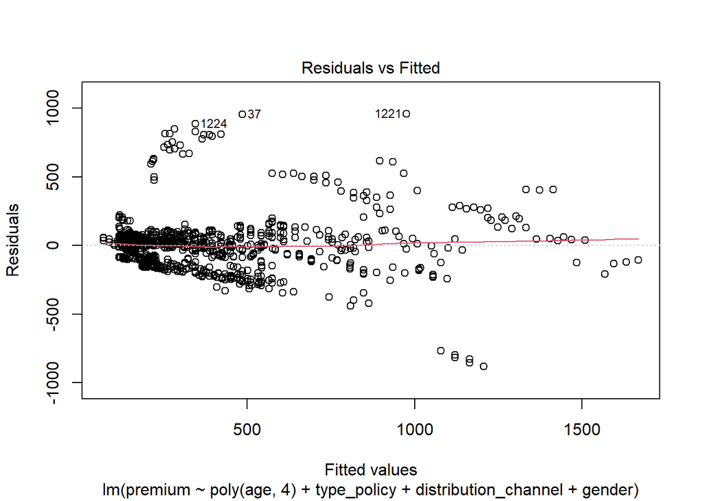

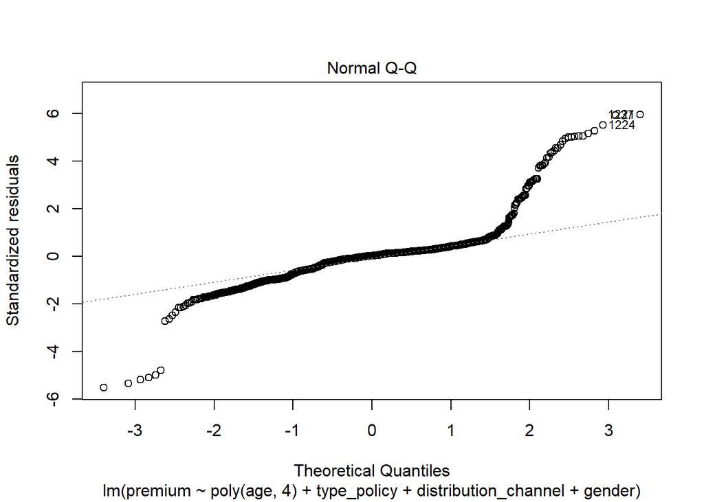

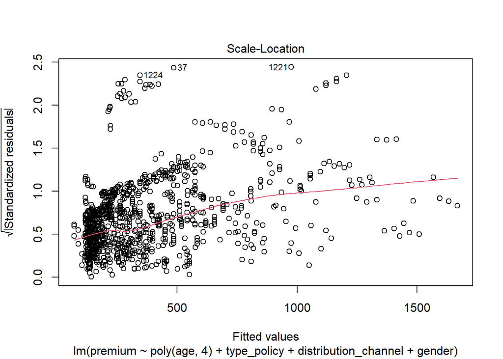

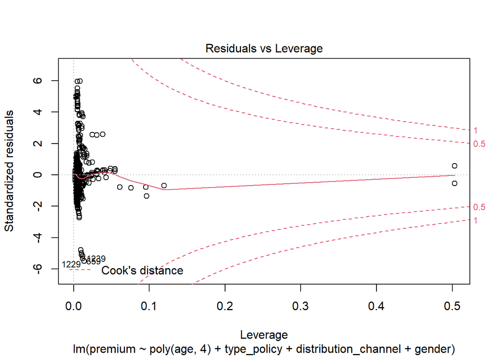

```r
plot(lin_modell_I_Yes)
```

#### als GLM mit Gamma Verteilung

Um der Tatsache Rechnung zu tragen, dass Prämien immer positiv sind, die Varianz der Residuen mit der Prämie steigt und hohe Werte häufiger als unter einer Normalverteilung angenommen auftreten, wird ein verallgemeinertes lineares Modell (GLM) mit Gamma‑Verteilung und Identitätslink geschätzt:

```r
glin_modell_I_Yes <- glm(
  premium ~  poly(age, 4) + type_policy + distribution_channel + gender,
  family = Gamma(link = "identity"),
  dt_I[reimbursement == "Yes"])

summary(glin_modell_I_Yes)
```

```
##
## Call:
## glm(formula = premium ~ poly(age, 4) + type_policy + distribution_channel +
##     gender, family = Gamma(link = "identity"), data = dt_I[reimbursement ==
##     "Yes"])
##
## Deviance Residuals:
##      Min        1Q    Median        3Q       Max
## -1.18086  -0.21704  -0.02653   0.12933   2.21007
##
## Coefficients:
##                       Estimate Std. Error t value Pr(>|t|)
## (Intercept)            334.178      7.830  42.678  < 2e-16 ***
## poly(age, 4)1         7386.700    328.087  22.514  < 2e-16 ***
## poly(age, 4)2         5818.886    437.802  13.291  < 2e-16 ***
## poly(age, 4)3          918.044    358.358   2.562 0.010512 *
## poly(age, 4)4         -707.109    194.437  -3.637 0.000286 ***
## type_policyC            -5.538      8.480  -0.653 0.513828
## distribution_channelA   13.558      8.700   1.558 0.119339
## distribution_channelD   16.419     78.132   0.210 0.833580
## genderM                  3.605      6.539   0.551 0.581583
## ---
## Signif. codes:  0 '***' 0.001 '**' 0.01 '*' 0.05 '.' 0.1 ' ' 1
##
## (Dispersion parameter for Gamma family taken to be 0.2829299)
##
##     Null deviance: 857.61  on 1479  degrees of freedom
## Residual deviance: 300.44  on 1471  degrees of freedom
## AIC: 18285
##
## Number of Fisher Scoring iterations: 11
```

Dieses Modell bildet die Varianzstruktur deutlich besser ab und reduziert den Einfluss der extrem hohen Prämienwerte auf die Schätzung des Erwartungswertes.

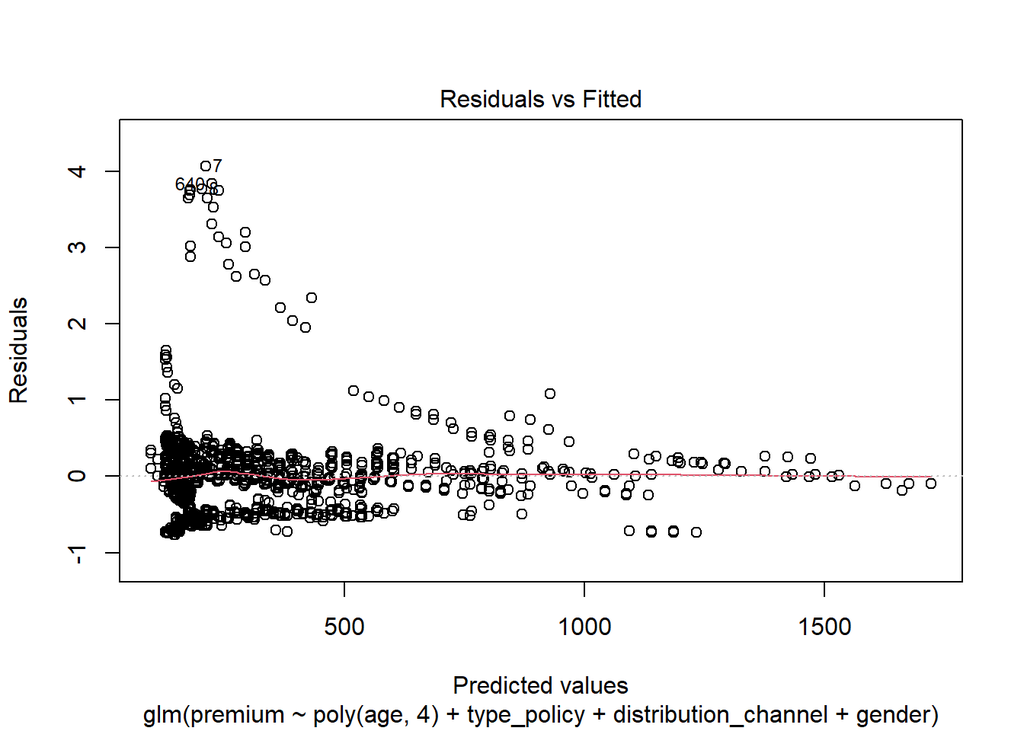

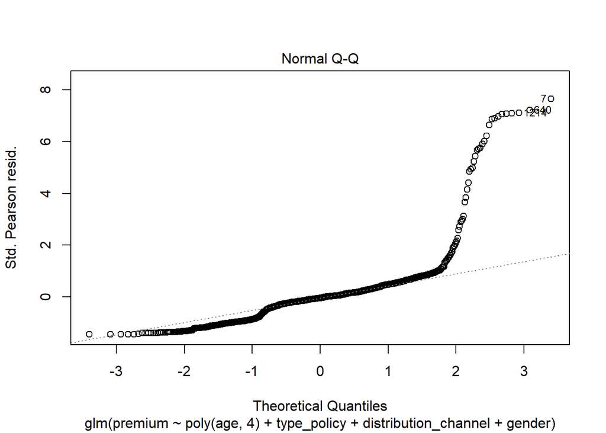

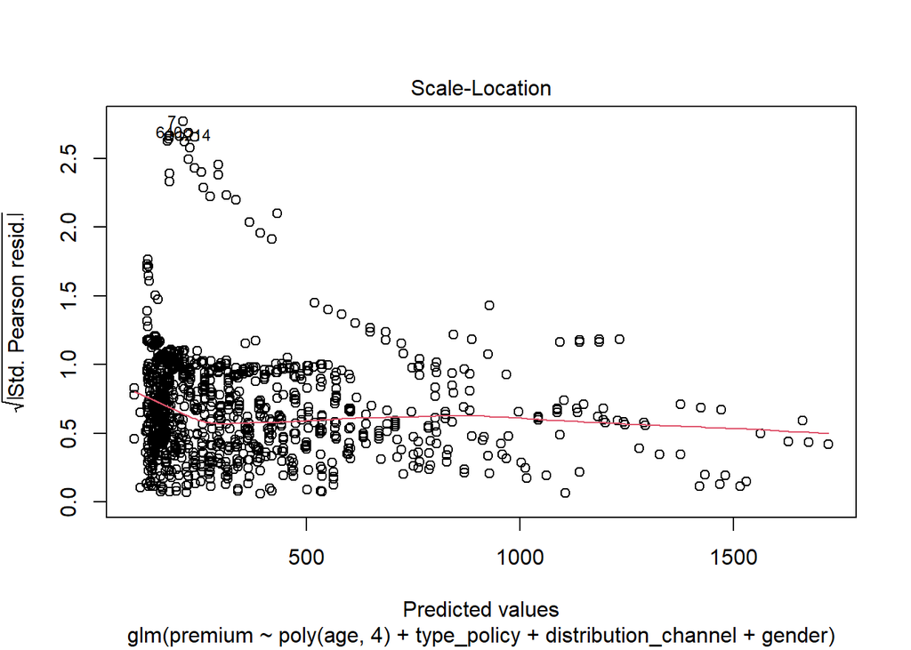

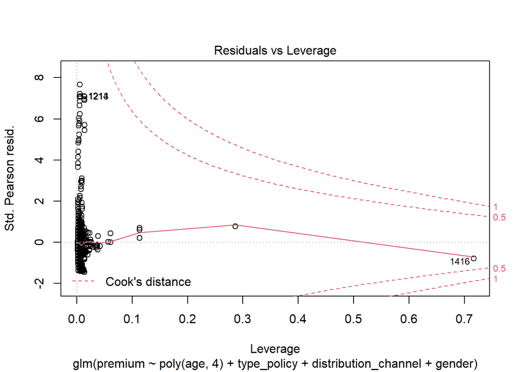

```r
plot(glin_modell_I_Yes)
```

### reimbursement = No

Für Tarife ohne Erstattung zeigen die Daten diskrete Alterssprünge für die Prämien. Das lässt sich mit zwei Indikatorvariablen im Modell abbilden:

- age60 = 1, falls Alter ≥ 60,
- age65 = 1, falls Alter ≥ 65.

```r
dt_I[, age60 := age >= 60]
dt_I[, age65 := age >= 65]
```

Da in diesem Segment keine Gruppenversicherungen mehr vorkommen, entfällt type_policy als Einflussfaktor. Es verbleiben:

- Altersindikatoren (age60, age65),
- distribution_channel,
- gender.

```r
dt_I[reimbursement == "No", list(Anzahl = .N), by = list(type_policy)]
```

```
##    type_policy Anzahl
## 1:           I   1537
```

Das lineare Modell lautet dann:

```r
lin_modell_I_No <- lm(premium ~  age60 +  age65 + distribution_channel + gender,
                      dt_I[reimbursement == "No"])

summary(lin_modell_I_No)
```

```
##
## Call:
## lm(formula = premium ~ age60 + age65 + distribution_channel +
##     gender, data = dt_I[reimbursement == "No"])
##
## Residuals:
##     Min      1Q  Median      3Q     Max
## -1296.0  -241.4   -92.5     7.8  3800.8
##
## Coefficients:
##                       Estimate Std. Error t value Pr(>|t|)
## (Intercept)             935.86      22.84  40.979   <2e-16 ***
## age60TRUE               524.04      49.94  10.493   <2e-16 ***
## age65TRUE               622.51      49.43  12.593   <2e-16 ***
## distribution_channelA  -181.35     154.29  -1.175     0.24
## genderM                  36.08      26.29   1.372     0.17
## ---
## Signif. codes:  0 '***' 0.001 '**' 0.01 '*' 0.05 '.' 0.1 ' ' 1
##
## Residual standard error: 509.9 on 1532 degrees of freedom
## Multiple R-squared:  0.5381, Adjusted R-squared:  0.5369
## F-statistic: 446.1 on 4 and 1532 DF,  p-value: < 2.2e-16
```

Die Diagnoseplots zeigen erneut, dass einzelne hohe Prämien (Risikozuschläge) die Varianz der Residuen stark erhöhen und es dort auch zur Verletzung der Normalverteilungsannahme führen.

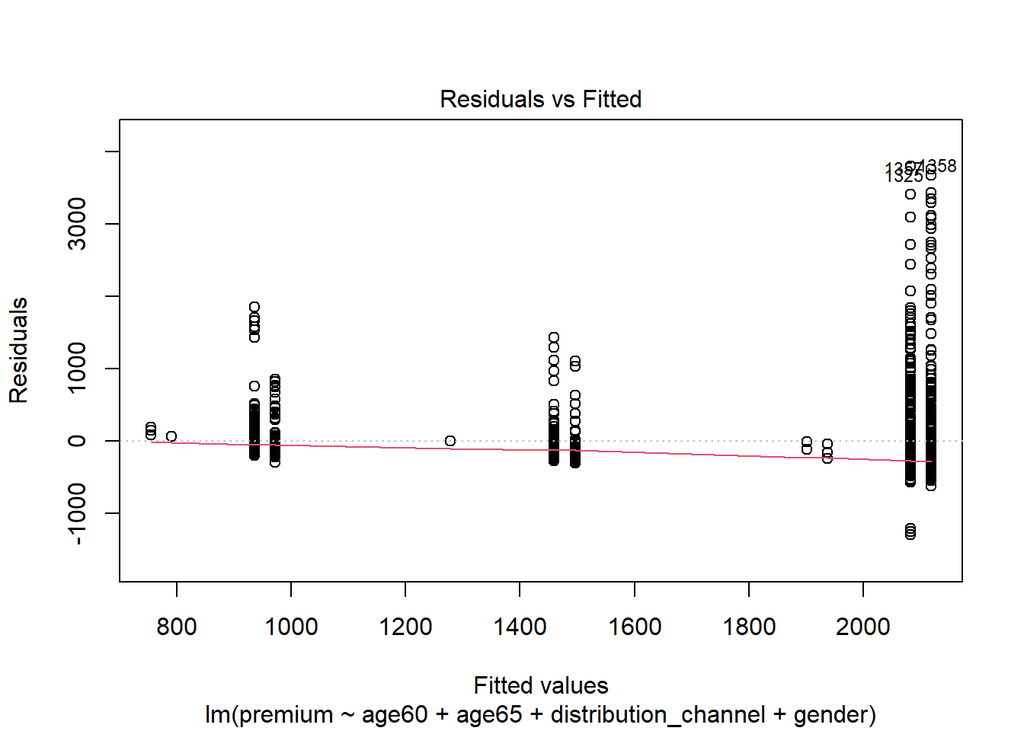

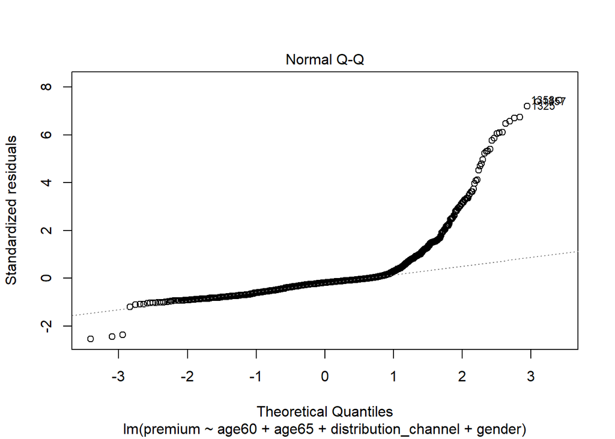

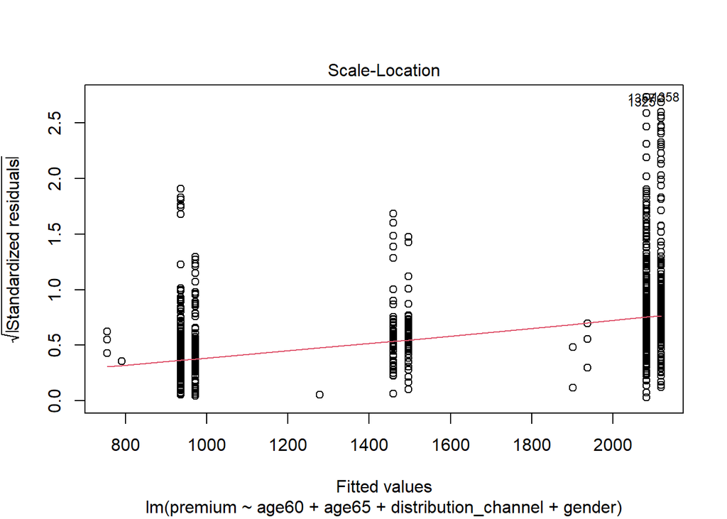

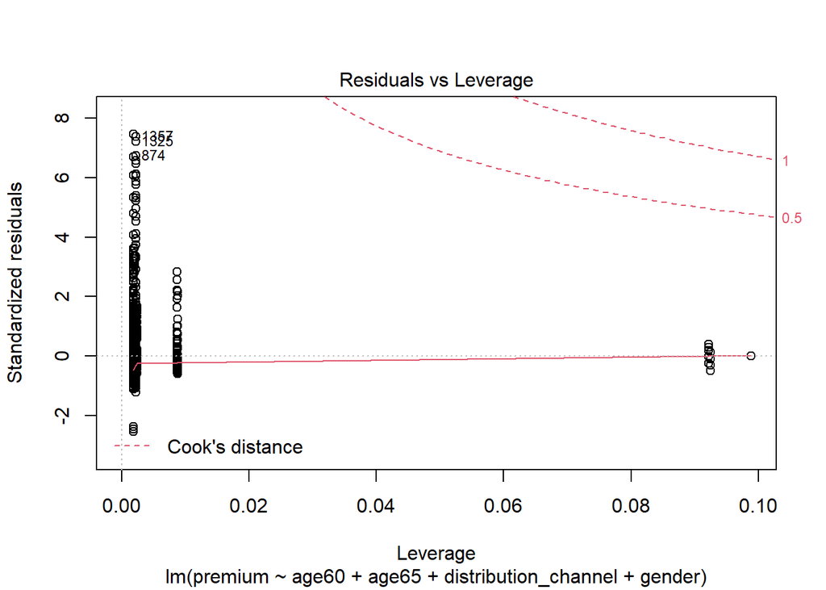

```r
plot(lin_modell_I_No)
```

### als GLM mit Gamma Verteilung

Aus Gründen der besseren Varianzmodellierung wird erneut ein GLM mit Gamma–Verteilung und Identitätslink geschätzt.

```r
glin_modell_I_No <- glm(
  premium ~  age60 +  age65 +  distribution_channel + gender,
  family = Gamma(link = "identity"),
  dt_I[reimbursement == "No"])

summary(glin_modell_I_No)
```

```
##
## Call:
## glm(formula = premium ~ age60 + age65 + distribution_channel +
##     gender, family = Gamma(link = "identity"), data = dt_I[reimbursement ==
##     "No"])
##
## Deviance Residuals:
##      Min        1Q    Median        3Q       Max
## -0.84446  -0.13915  -0.08179   0.00683   1.30439
##
## Coefficients:
##                       Estimate Std. Error t value Pr(>|t|)
## (Intercept)            953.057     13.044  73.063   <2e-16 ***
## age60TRUE              526.148     38.597  13.632   <2e-16 ***
## age65TRUE              620.352     42.895  14.462   <2e-16 ***
## distribution_channelA -110.206     94.568  -1.165    0.244
## genderM                 -5.556     18.301  -0.304    0.761
## ---
## Signif. codes:  0 '***' 0.001 '**' 0.01 '*' 0.05 '.' 0.1 ' ' 1
##
## (Dispersion parameter for Gamma family taken to be 0.07864671)
##
##     Null deviance: 294.188  on 1536  degrees of freedom
## Residual deviance:  82.552  on 1532  degrees of freedom
## AIC: 22192
##
## Number of Fisher Scoring iterations: 5
```

Ein GLM mit Gamma‑Verteilung und Identitätslink führt entsprechend zu einer besseren Modellierung der Varianzstruktur. Trotzdem bleiben extreme Werte problematisch. Leider kann bei einem verallgemeinerten linearen Modell keine Verteilung mit stark ausgeprägten Randbereichen, wie bei einer Pareto‑Verteilung, verwendet werden.

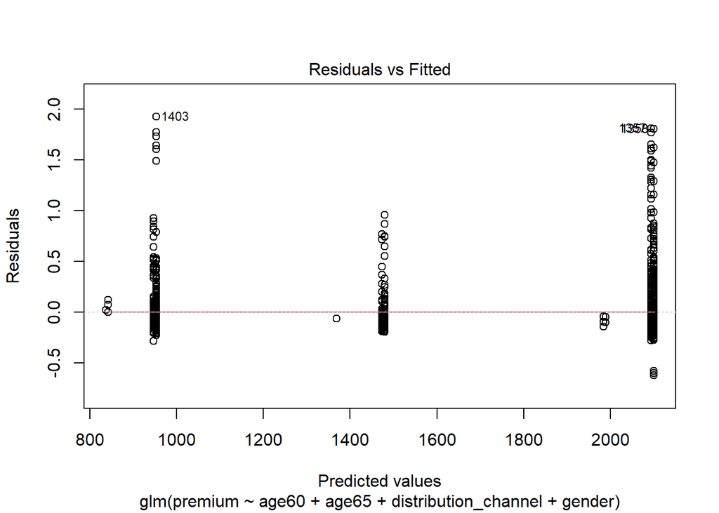

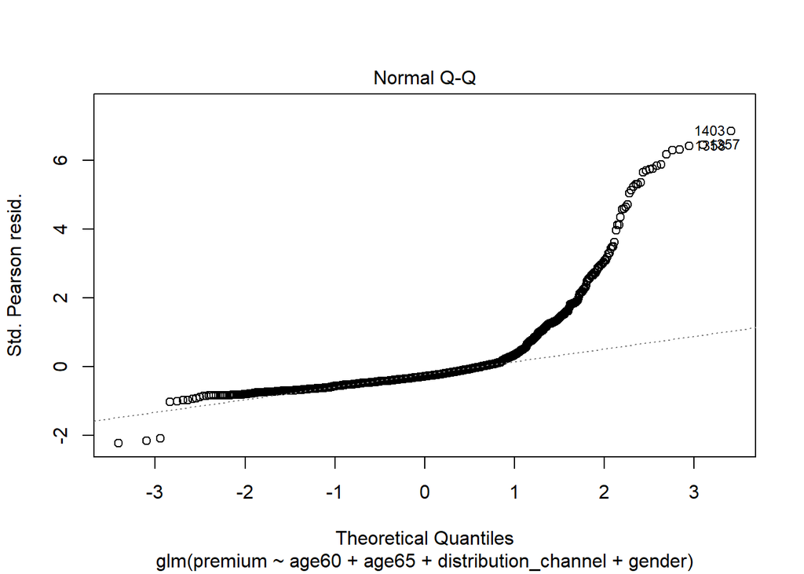

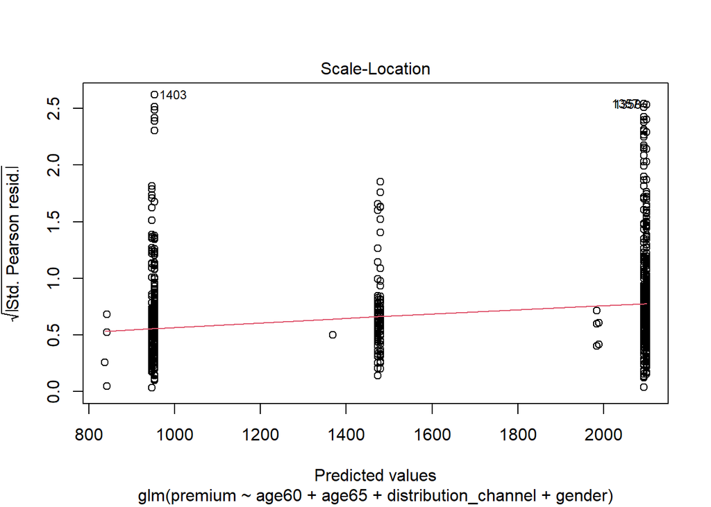

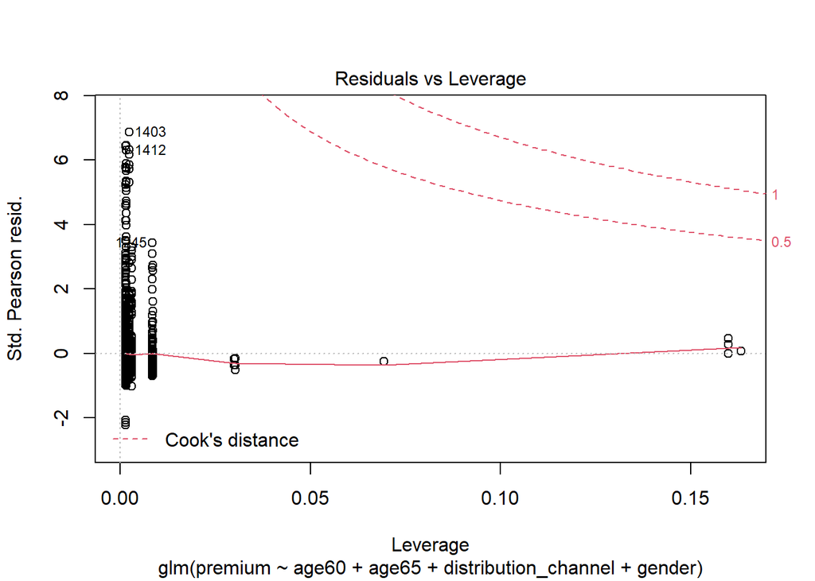

```r
plot(glin_modell_I_No)
```

## Gemeinsame Modellierung für S und P

Da S (Standard) und P (Premium) im Wesentlichen die gleichen medizinischen Leistungen abdecken, erscheint eine gemeinsame Modellierung dieser beiden Produktlinien sinnvoll. type_product bleibt dabei als erklärende Variable im Modell enthalten, um unterschiedliche Prämienniveaus abzubilden.

Die Erstattungsart folgt bei diesen Produkten aus type_product und muss daher nicht separat modelliert werden. Als Einflussfaktoren werden berücksichtigt:

- type_product (S vs. P),
- type_policy_dg (feine Aufteilung der Vertragstypen: Individual, Self-Employed, Collective 1–4),
- distribution_channel (I, A, D),
- gender (F, M),
- age (als kontinuierliche Variable).

Referenz für die kategoriellen Variablen sollte die größte Gruppe sein.

```r
dt_SP <- dt[type_product %in% c("S", "P"), list(
  type_product,
  type_policy_dg = factor(type_policy_dg, c("I", "SE", "C1", "C2", "C3", "C4"), c("I", "SE", "C1", "C2", "C3", "C4")),
  distribution_channel = factor(distribution_channel, c("I", "A", "D")),
  gender = factor(gender, c("F", "M"), c("F", "M")),
  age,
  premium
)]
```

Aufgrund der komplexen Altersstruktur und der Interaktion mit den kategorialen Variablen wird anstelle hoher Polynome ein Splines-Ansatz gewählt. Mit B‑Splines (bs(age, df = 10)) wird das Altersprofil flexibel und insbesondere lokal kontrolliert modelliert.

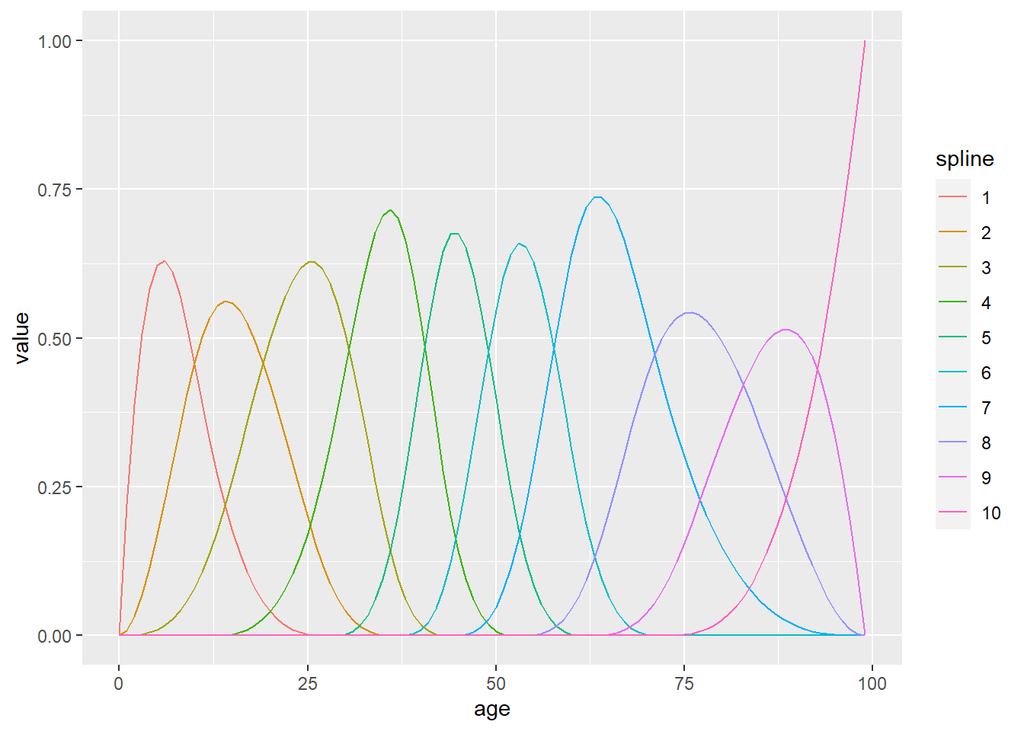

```r
spl <- data.table(age = dt_SP$age, bs(dt_SP$age, df = 10))
spl <- unique(spl)[order(age)]

spl <- melt(spl,id.vars = "age",  variable.name = "spline")

ggplot(spl, aes(x = age, y = value, col = spline)) +
  geom_line()
```

Die verwendete Modellform ist ein lineares Modell mit Interaktion aller kategorialen Faktoren mit den Alters‑Splines.

Die Modellzusammenfassung zeigt:

- Signifikante Effekte der Produktart und des Produkttyps, insbesondere in höheren Alterssegmenten,
- signifikante Unterschiede zwischen den Vertriebskanälen,
- Geschlechtereffekte sind vorhanden, aber im Vergleich zu anderen Faktoren weniger dominant.

Die Varianz der Fehler ist hoch relativ im Vergleich zum Prämienniveau der jüngeren Versicherten, was angesichts der teilweise sehr hohen Prämien im hohen Alter nicht überrascht. Auch R^2 ist nicht befriedigend, erklärt sich aber aus der unvollständig beobachteten Tarifstruktur (fehlende Produktlinienkennzeichnung, Risikozuschläge).

```r
lin_modell_SP <- lm(premium ~  type_product * bs(age, df = 10) +
                      type_policy_dg * bs(age, df = 10) +
                      distribution_channel * bs(age, df = 10) +
                      gender * bs(age, df = 10),
                    dt_SP)

summary(lin_modell_SP)
```

```
##
## Call:
## lm(formula = premium ~ type_product * bs(age, df = 10) + type_policy_dg *
##     bs(age, df = 10) + distribution_channel * bs(age, df = 10) +
##     gender * bs(age, df = 10), data = dt_SP)
##
## Residuals:
##     Min      1Q  Median      3Q     Max
## -1623.3  -173.5   -27.3   126.2 20668.3
##
## Coefficients:
##                                            Estimate Std. Error t value Pr(>|t|)
## (Intercept)                               5.796e+02  1.604e+01  36.134  < 2e-16
## type_productS                             2.735e+01  1.449e+01   1.887 0.059177
## bs(age, df = 10)1                        -1.239e+02  3.095e+01  -4.005 6.21e-05
## bs(age, df = 10)2                        -2.332e+01  2.480e+01  -0.940 0.347140
## bs(age, df = 10)3                         1.229e+02  2.650e+01   4.636 3.55e-06
## bs(age, df = 10)4                         2.258e+02  1.973e+01  11.447  < 2e-16
## bs(age, df = 10)5                         2.883e+02  2.206e+01  13.071  < 2e-16
## bs(age, df = 10)6                         5.483e+02  2.237e+01  24.508  < 2e-16
## bs(age, df = 10)7                         7.415e+02  2.322e+01  31.937  < 2e-16
## bs(age, df = 10)8                         2.263e+03  3.868e+01  58.508  < 2e-16
## bs(age, df = 10)9                         2.322e+03  6.433e+01  36.087  < 2e-16
## bs(age, df = 10)10                        1.686e+03  1.157e+02  14.571  < 2e-16
## type_policy_dgSE                         -7.586e+01  1.833e+01  -4.138 3.50e-05
## type_policy_dgC1                         -1.312e+02  1.986e+01  -6.608 3.91e-11
## type_policy_dgC2                         -1.971e+02  7.773e+01  -2.536 0.011206
## type_policy_dgC3                          1.471e+02  3.301e+01   4.457 8.32e-06
## type_policy_dgC4                         -1.844e+02  3.548e+01  -5.197 2.03e-07
## distribution_channelA                    -2.001e+01  1.385e+01  -1.445 0.148565
## distribution_channelD                    -1.196e+02  3.893e+01  -3.071 0.002135
## genderM                                  -8.472e-02  1.319e+01  -0.006 0.994875
## type_productS:bs(age, df = 10)1           2.445e+01  2.756e+01   0.887 0.375084
## type_productS:bs(age, df = 10)2           6.862e+00  2.212e+01   0.310 0.756331
## type_productS:bs(age, df = 10)3           1.582e+00  2.403e+01   0.066 0.947503
## type_productS:bs(age, df = 10)4          -5.839e+01  1.780e+01  -3.279 0.001041
## type_productS:bs(age, df = 10)5           6.554e+00  2.000e+01   0.328 0.743097
## type_productS:bs(age, df = 10)6          -7.071e+01  2.054e+01  -3.443 0.000576
## type_productS:bs(age, df = 10)7           6.856e+01  2.180e+01   3.145 0.001658
## type_productS:bs(age, df = 10)8          -1.190e+03  3.840e+01 -30.997  < 2e-16
```

[output cut: 184 more lines]

```
## bs(age, df = 10)2:genderM
## bs(age, df = 10)3:genderM
## bs(age, df = 10)4:genderM                *
## bs(age, df = 10)5:genderM
## bs(age, df = 10)6:genderM                **
## bs(age, df = 10)7:genderM
## bs(age, df = 10)8:genderM
## bs(age, df = 10)9:genderM
## bs(age, df = 10)10:genderM               **
## ---
## Signif. codes:  0 '***' 0.001 '**' 0.01 '*' 0.05 '.' 0.1 ' ' 1
##
## Residual standard error: 393.4 on 215718 degrees of freedom
## Multiple R-squared:  0.4692, Adjusted R-squared:  0.469
## F-statistic:  1750 on 109 and 215718 DF,  p-value: < 2.2e-16
```

```r
AIC(lin_modell_SP)
```

```
## [1] 3191644
```

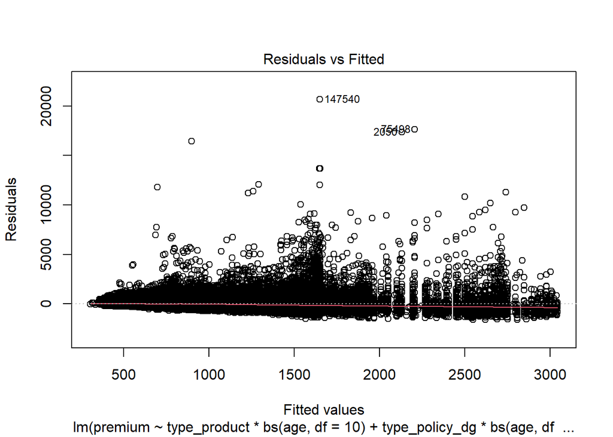

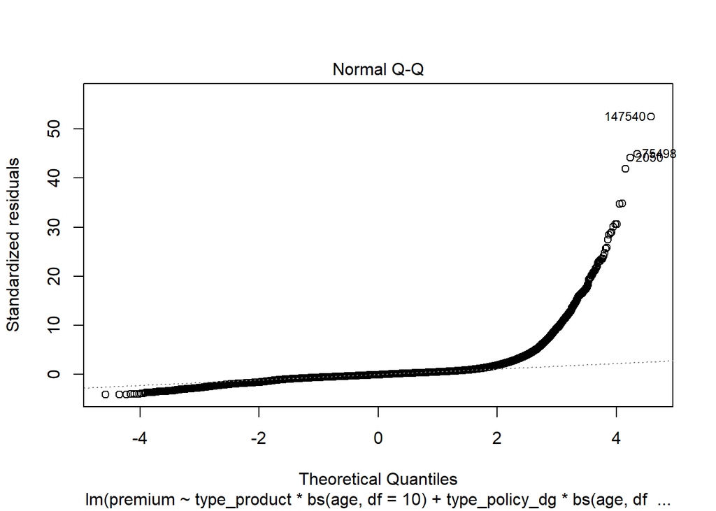

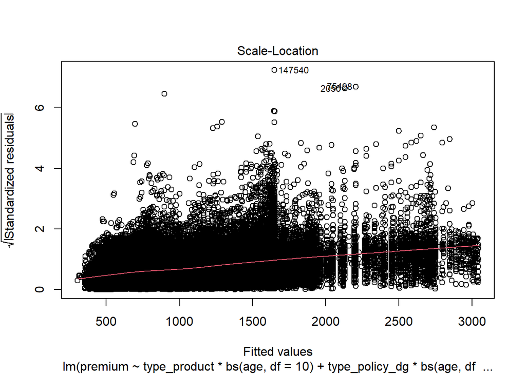

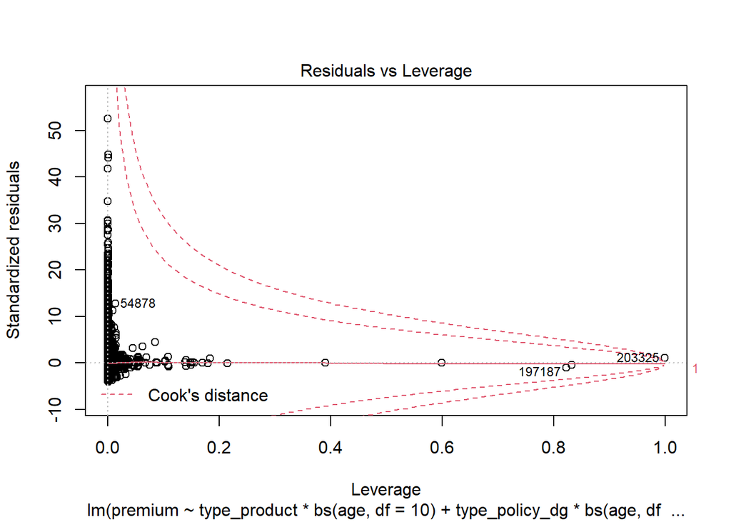

```r
plot(lin_modell_SP)
```

### als GLM mit Gamma Verteilung

Aus Gründen der besseren Varianzmodellierung wird erneut ein GLM mit Gamma‑Verteilung und Identitätslink geschätzt.

```r
glin_modell_SP <- glm(premium ~  type_product * bs(age, df = 10) +
                      type_policy_dg * bs(age, df = 10) +
                      distribution_channel * bs(age, df = 10) +
                      gender * bs(age, df = 10),
                      family = Gamma(link = "identity"),
                    dt_SP)

summary(glin_modell_SP)
```

```
##
## Call:
## glm(formula = premium ~ type_product * bs(age, df = 10) + type_policy_dg *
##     bs(age, df = 10) + distribution_channel * bs(age, df = 10) +
##     gender * bs(age, df = 10), family = Gamma(link = "identity"),
##     data = dt_SP)
##
## Deviance Residuals:
##     Min       1Q   Median       3Q      Max
## -2.0985  -0.2340  -0.0353   0.1479   5.4078
##
## Coefficients:
##                                            Estimate Std. Error t value Pr(>|t|)
## (Intercept)                               5.830e+02  7.708e+00  75.634  < 2e-16
## type_productS                             3.388e+01  6.713e+00   5.047 4.50e-07
## bs(age, df = 10)1                        -1.277e+02  1.463e+01  -8.728  < 2e-16
## bs(age, df = 10)2                        -3.282e+01  1.204e+01  -2.725 0.006423
## bs(age, df = 10)3                         1.226e+02  1.428e+01   8.587  < 2e-16
## bs(age, df = 10)4                         1.965e+02  1.078e+01  18.226  < 2e-16
## bs(age, df = 10)5                         2.975e+02  1.332e+01  22.345  < 2e-16
## bs(age, df = 10)6                         4.905e+02  1.584e+01  30.958  < 2e-16
## bs(age, df = 10)7                         7.820e+02  2.067e+01  37.830  < 2e-16
## bs(age, df = 10)8                         2.096e+03  5.639e+01  37.170  < 2e-16
## bs(age, df = 10)9                         2.605e+03  1.207e+02  21.582  < 2e-16
## bs(age, df = 10)10                        1.554e+03  2.394e+02   6.492 8.48e-11
## type_policy_dgSE                         -7.703e+01  8.284e+00  -9.300  < 2e-16
## type_policy_dgC1                         -1.361e+02  8.266e+00 -16.465  < 2e-16
## type_policy_dgC2                         -2.030e+02  2.932e+01  -6.924 4.39e-12
## type_policy_dgC3                          1.401e+02  2.120e+01   6.610 3.85e-11
## type_policy_dgC4                         -1.935e+02  1.378e+01 -14.037  < 2e-16
## distribution_channelA                    -2.737e+01  6.631e+00  -4.127 3.68e-05
## distribution_channelD                    -1.224e+02  1.674e+01  -7.314 2.61e-13
## genderM                                  -1.430e+00  6.138e+00  -0.233 0.815759
## type_productS:bs(age, df = 10)1           2.294e+01  1.250e+01   1.836 0.066365
## type_productS:bs(age, df = 10)2           8.708e+00  1.021e+01   0.853 0.393636
## type_productS:bs(age, df = 10)3          -1.606e+00  1.241e+01  -0.129 0.897079
## type_productS:bs(age, df = 10)4          -4.909e+01  9.333e+00  -5.260 1.44e-07
## type_productS:bs(age, df = 10)5           9.233e-01  1.159e+01   0.080 0.936486
## type_productS:bs(age, df = 10)6          -3.068e+01  1.412e+01  -2.173 0.029813
## type_productS:bs(age, df = 10)7           5.480e+01  1.939e+01   2.827 0.004706
```

[output cut: 189 more lines]

```
## bs(age, df = 10)6:genderM                ***
## bs(age, df = 10)7:genderM
## bs(age, df = 10)8:genderM
## bs(age, df = 10)9:genderM
## bs(age, df = 10)10:genderM               **
## ---
## Signif. codes:  0 '***' 0.001 '**' 0.01 '*' 0.05 '.' 0.1 ' ' 1
##
## (Dispersion parameter for Gamma family taken to be 0.1206839)
##
##     Null deviance: 51696  on 215827  degrees of freedom
## Residual deviance: 20158  on 215718  degrees of freedom
## AIC: 2981699
##
## Number of Fisher Scoring iterations: 6
```

Hier zeigt sich:

- Das Modell bildet die Varianzstruktur deutlich besser ab.
- Der AIC ist im Vergleich zum Gauß-Modell deutlich geringer, was auf eine insgesamt bessere Modellgüte hindeutet.
- Extreme, sehr hohe Prämienwerte treten immer noch häufiger auf als unter der Gammaannahme zu erwarten wäre. Da die Exponentialfamilien von Verteilungen definitionsgemäß keine stark ausgeprägten Randbereiche zulassen, bleiben diese Ausreißer eine Herausforderung.

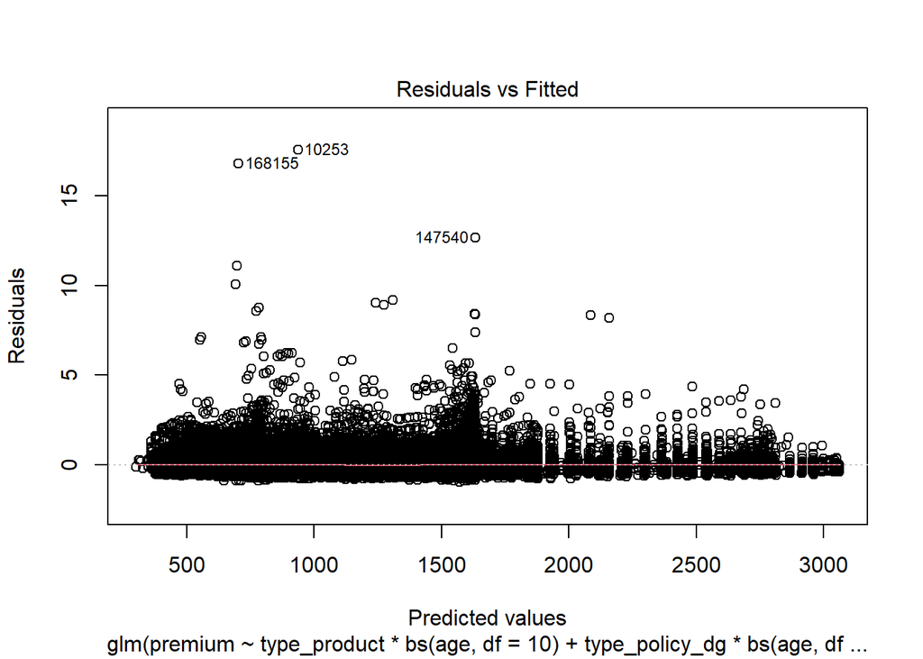

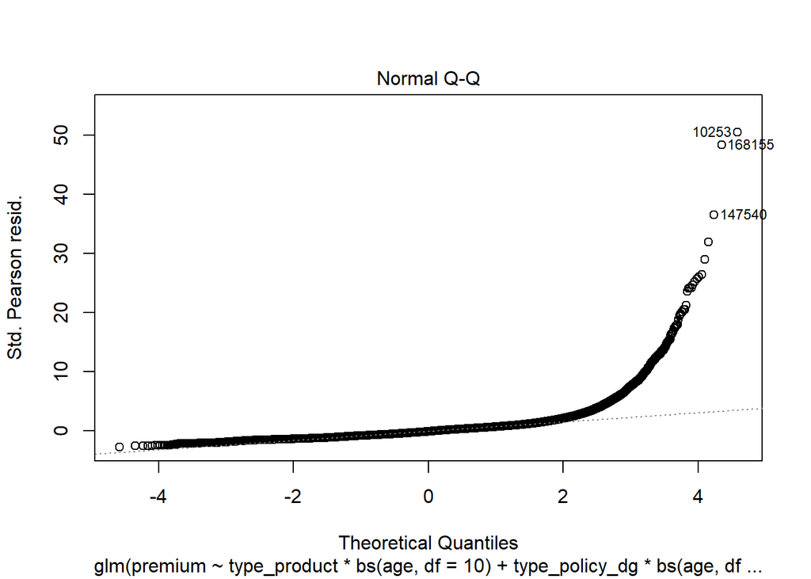

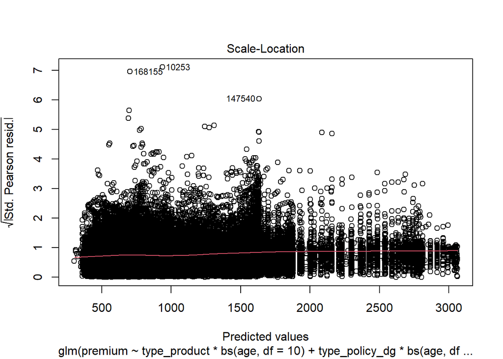

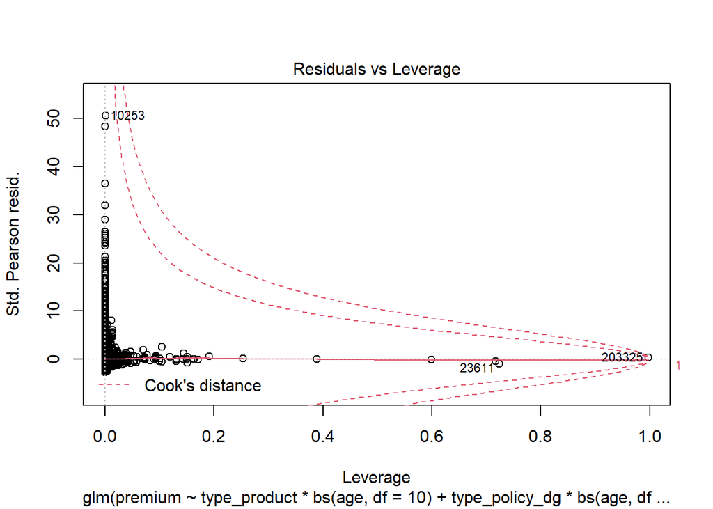

```r
plot(glin_modell_SP)
```

# Fazit

Die Analyse zeigt:

- Eine starke Segmentierung des Portfolios nach Produktart, Erstattungsform, Vertriebsweg und Produkttyp,
- ausgeprägte Altersabhängigkeiten insbesondere bei den Standard- und Premiumprodukten,
- Diskretisierung im Altersprofil bei internationalen Tarifen ohne Erstattung,
- punktuelle, teilweise sehr hohe Prämienwerte, die sich plausibel als Risikozuschläge interpretieren lassen.

Die gewählten linearen Modelle ermöglichen es zentrale Einflussgrößen auf das Prämienniveau zu quantifizieren. Durch den Wechsel zu Gamma‑GLMs kann die heterogene Varianzstruktur besser abgebildet werden. Gleichzeitig werden Grenzen deutlich:

- Wichtige Strukturinformationen (z.B. konkrete Produktlinien, Höhe und Anlass von Risikozuschlägen, genaue Leistungsumfänge) sind im Datensatz nicht enthalten.
- Die Modelle können daher nur einen Teil der beobachteten Variation erklären und sollten eher als explorative Werkzeuge, denn als produktionsreife Tarifmodelle verstanden werden.

Insgesamt liefert das Skript einen strukturierten Einstieg in die Analyse von Krankenversicherungsprämien und zeigt, wie mit einfachen Mitteln schrittweise von der deskriptiven Betrachtung zu geeigneten Regressions- und GLM‑Modellen übergegangen werden kann.

Mögliche Erweiterungen wären:

- Einbeziehung von der Schadendaten, um die Prämienstruktur mit der Leistungsseite zu verknüpfen,
- Untersuchung des Einflusses der Regiodaten auf Prämien und Leistung.
- Analyse der Stornodaten unter Berücksichtigung von Prämien und Leistung.